# Project Proposal: Classifying Pulsar Stars

## Introduction

**Background Information and Question**

A pulsar is a highly magnetised rotating neutron star. They emit regular pulses of electromagnetic radiation (specifically radio waves) from their magnetic poles. These pulses produce a periodically repeating detectable pattern of broadband radio emission. Individual pulsars are unique in their emission patterns, which vary with each rotation.

Radio waves from pulsars, observed through large radio telescopes, are used by astronomers to estimate the distances of cosmic objects. Possible signal detections, candidates, are averaged over many rotations before classifying them to. Radio Frequency Interference (RFI) and noise are the root causes of most detections and make identifying pulsars difficult.

**The predictive question we aim to answer through this project is:** *Can we predict the class of our unclassified pulsar star dataset using the four integrated profiles?*

**Dataset Used**

University of Manchester’s Pulsar Star dataset will be used for this project. The pulsar candidates in this dataset were collected during the High Time Resolution Universe Survey (South).

Each row represents a pulsar candidate. Eight continuous variables (mean, standard deviation, excess kurtosis and skewness of both the integrated pulse profile and the DM-SNR curve) and one class variable describe each candidate. The class label, represented in the last column, has a value of 1 for a real pulsar and 0 otherwise. The sum of many individual pulsar star pulses, the pulsar’s fingerprint, is the integrated pulse profile. The background radio waves that may interfere with the desired signal is the DM-SNR (Dispersion Measure Signal-to-Noise Ratio) curve.

## Preliminary exploratory data analysis

```r
#importing neccesary libaries
library(tidyverse)
library(tidymodels)
library(repr)
```

**Reading the dataset from the web**

```r
temp <- tempfile()
download.file("https://archive.ics.uci.edu/ml/machine-learning-databases/00372/HTRU2.zip", temp)
pulsar_file <- unz(temp, "HTRU_2.csv")
pulsar <- read_csv(pulsar_file, col_names = FALSE)
```

**Cleaning and wrangling the data into a tidy format**

```r
colnames(pulsar) <- c("mean_ip", "std_ip", "kurt_ip", "skew_ip", "mean_dm_snr", "std_dm_snr", "kurt_dm_snr", "skew_dm_snr", "class")
pulsar <- pulsar |> mutate(class = as_factor(class))
```

**Separating the dataset into training and testing sets**

```r
pulsar_split <- initial_split(pulsar, prop = 0.75, strata = class)
pulsar_train <- training(pulsar_split)
pulsar_test <- testing(pulsar_split)
```

```r
pulsar
```

A tibble: 17898 × 9

| mean_ip <dbl> | std_ip <dbl> | kurt_ip <dbl> | skew_ip <dbl> | mean_dm_snr <dbl> | std_dm_snr <dbl> | kurt_dm_snr <dbl> | skew_dm_snr <dbl> | class <fct> |
| --- | --- | --- | --- | --- | --- | --- | --- | --- |
| 140.5625 | 55.68378 | -0.2345714 | -0.6996484 | 3.199833 | 19.11043 | 7.975532 | 74.24222 | 0 |
| 102.5078 | 58.88243 | 0.4653182 | -0.5150879 | 1.677258 | 14.86015 | 10.576487 | 127.39358 | 0 |
| 103.0156 | 39.34165 | 0.3233284 | 1.0511644 | 3.121237 | 21.74467 | 7.735822 | 63.17191 | 0 |
| ⋮ | ⋮ | ⋮ | ⋮ | ⋮ | ⋮ | ⋮ | ⋮ | ⋮ |
| 119.3359 | 59.93594 | 0.1593631 | -0.74302540 | 21.430602 | 58.87200 | 2.499517 | 4.595173 | 0 |
| 114.5078 | 53.90240 | 0.2011614 | -0.02478884 | 1.946488 | 13.38173 | 10.007967 | 134.238910 | 0 |
| 57.0625 | 85.79734 | 1.4063910 | 0.08951971 | 188.306020 | 64.71256 | -1.597527 | 1.429475 | 0 |

```r
#Centering each variable in the dataset
pulsar_train_scaled <- pulsar_train %>%
 mutate(mean_ip = scale(mean_ip, center = TRUE),
        std_ip = scale(std_ip, center = TRUE),
        kurt_ip = scale(kurt_ip, center = TRUE),
        skew_ip = scale(skew_ip, center = TRUE),
        mean_dm_snr = scale(mean_dm_snr, center = TRUE),
        std_dm_snr = scale(std_dm_snr, center = TRUE),
        kurt_dm_snr = scale(kurt_dm_snr, center = TRUE),
        skew_dm_snr = scale(skew_dm_snr, center = TRUE))
pulsar_train_scaled
```

A tibble: 13423 × 9

| mean_ip <dbl[,1]> | std_ip <dbl[,1]> | kurt_ip <dbl[,1]> | skew_ip <dbl[,1]> | mean_dm_snr <dbl[,1]> | std_dm_snr <dbl[,1]> | kurt_dm_snr <dbl[,1]> | skew_dm_snr <dbl[,1]> | class <fct> |
| --- | --- | --- | --- | --- | --- | --- | --- | --- |
| 1.151344 | 1.339710 | -0.672653694 | -0.4023267 | -0.3192844 | -0.3713410 | -0.07127109 | -0.2873120 | 0 |
| -0.336565 | 1.809623 | -0.008077059 | -0.3718608 | -0.3708874 | -0.5894290 | 0.50702043 | 0.2150586 | 0 |
| -0.316710 | -1.061112 | -0.142902753 | -0.1133152 | -0.3219482 | -0.2361743 | -0.12456772 | -0.3919453 | 0 |
| ⋮ | ⋮ | ⋮ | ⋮ | ⋮ | ⋮ | ⋮ | ⋮ | ⋮ |
| 0.9897543 | 1.9513901 | -0.6282854 | -0.4086778 | -0.3837810 | -0.7276662 | 1.5906463 | 1.7135067 | 0 |
| 0.4472524 | 0.4291361 | -0.3283966 | -0.2335053 | 0.1284229 | 0.9379452 | -1.1896959 | -0.9106055 | 0 |
| 0.1326258 | 1.0780072 | -0.2589058 | -0.2909258 | -0.3617626 | -0.6652885 | 0.3806169 | 0.2797586 | 0 |

**Exploratory data analysis**

```r
#counting pulsar classified as 0's and 1's
count_train_pulsar <- pulsar_train |>
    group_by(class) |>
    summarize(n = n())
count_train_pulsar
```

A tibble: 2 × 2

| class <fct> | n <int> |
| --- | --- |
| 0 | 12201 |
| 1 | 1222 |

```r
#checking for missing values in training data
sum(is.na(pulsar_train))
```

0

**Visualization**

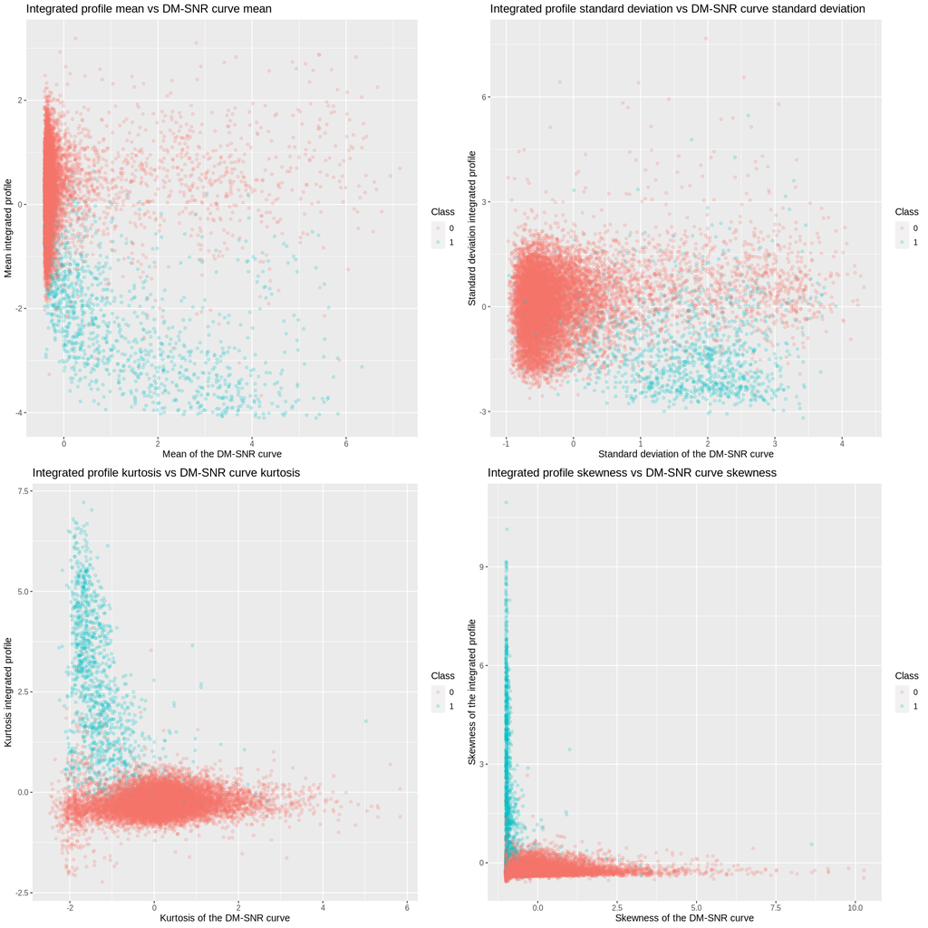

```r
options(repr.plot.width = 16, repr.plot.height = 16)

plot_mean_ip_dmsnr <- ggplot(pulsar_train_scaled, aes(x = mean_dm_snr, y = mean_ip , color = class)) +
                geom_point(alpha = 0.2) +
                labs(x = "Mean of the DM-SNR curve", y = "Mean integrated profile", color = "Class") +
                theme(text = element_text(size = 12)) +
                ggtitle("Integrated profile mean vs DM-SNR curve mean")

plot_std_ip_dmsnr <- ggplot(pulsar_train_scaled, aes(x = std_dm_snr, y = std_ip , color = class)) +
                geom_point(alpha = 0.2) +
                labs(x = "Standard deviation of the DM-SNR curve", y = "Standard deviation integrated profile", color = "Class") +
                theme(text = element_text(size = 12)) +
                ggtitle("Integrated profile standard deviation vs DM-SNR curve standard deviation")

plot_kurt_ip_dmsnr <- ggplot(pulsar_train_scaled, aes(x = kurt_dm_snr, y = kurt_ip , color = class)) +
                geom_point(alpha = 0.2) +
                labs(x = "Kurtosis of the DM-SNR curve", y = "Kurtosis integrated profile", color = "Class") +
                theme(text = element_text(size = 12)) +
                ggtitle("Integrated profile kurtosis vs DM-SNR curve kurtosis")

plot_skew_ip_dmsnr <- ggplot(pulsar_train_scaled, aes(x = skew_dm_snr, y = skew_ip , color = class)) +
                geom_point(alpha = 0.2) +
                labs(x = "Skewness of the DM-SNR curve", y = "Skewness of the integrated profile", color = "Class") +
                theme(text = element_text(size = 12)) +
                ggtitle("Integrated profile skewness vs DM-SNR curve skewness")

plot_grid(plot_mean_ip_dmsnr, plot_std_ip_dmsnr, plot_kurt_ip_dmsnr, plot_skew_ip_dmsnr, ncol = 2, nrow = 2)
```

## Methods

The first step was to read the dataset into Jupyter, using the readcsv function. Column names were then assigned and the categorical variable (class) was changed from dbl to fct. All eight continuous variables have been used throughout the preliminary exploratory data analysis. Scatter plots with DM-SNR curves (mean, standard deviation, excess kurtosis, or skewness) on the x-axis and integrated profiles on the y-axis, are used to visualize the relationships between continuous variables. For better visualization, the points are coloured according to their class. To determine the value of k to be used, the K-nearest neighbour classification and cross-validation methods will be used. The model will also be subjected to 5 fold tuning to maximize the accuracy. These steps will be repeated for all eight continuous variables.

## Expected outcomes and significance

**What do you expect to find?**

The plots for kurtosis and skewness have a very similar pattern and division of the two classes of stars. Class 0 is concentrated in a lower range whereas class 1 is concentrated in a higher range for both visualizations. This leads us to infer that these two variables are reliable predictors.

**What impact could such findings have?**

These findings could assist in a quicker identification of real pulsar. This would be of great help in the measurement of distances in space, study of extreme matter states, planet exploration beyond our solar system, and may even be of use in the study of blackholes. These would all lead to advances in astronomical research.

**What future questions could this lead to?**

Why do pulsar stars have those predictor variable characteristics?

Is there a threshold value for each continuous variable, after which a candidate is classified as a real pulsar?